# Project (Signature Assignment)

#### HARSH SHAH (001273963)

#### DA5030 | 35664 | Intro Data Mining & Machine Learning | SEC 01 | Spring 2018

### Project (Signature Assignment): “Credit Risk Prediction Classification Analysis”

#### This Signature Project provided me with an opportunity to complete a substantial effort where I can showcase my understanding of Data Mining and Machine Learning techniques that I studied in this course.

#### Dataset: “Credit Card Fraud Detection” - https://www.kaggle.com/mlg-ulb/creditcardfraud/data

#### Followed: Phases of CRISP-DM and Project Rubric format

### Phase 1 - Business Understanding:

#### Providing credits to the customer has certainly became a huge concerns for the banks nowadays. They eventually plans to proceed in a way to accurately identify the customer whether to be a defaulter or genuine.

#### I will leverage Data Mining and Machine Learning techniques to provide the solutions to the banks in terms of evaluted and improved machine learning generalized predictive model which will analyze and classifies the risks related to providing credit to the customer with highest accuracy.

#### After productizing the model through the data-pipeline, banks will be able to evaluate and detect the risks involved in providing credit to the customer which will eventually help them reduce their capital loss and business will consequently grow much faster.

### Phase 2 - Data Understanding:

#### Dataset contains transactions made by credit cards by European cardholders. Transactions presented have occurred in two days. There are total 31 feature variables including response variable, which depicts high dimensionality having 284,807 records of which 492 are labeled as fraud (i.e. 1) and rest as genuine (i.e. 0).

#### The dataset contains only numeric input feature variables which are the result of PCA transformation. Due to confidentiality issues, bank cannot provide the original feature variables and more background information on it. AlThough this issue, we would be definitely capable to initiate the analysis and provision the precise & more accurate results.

#### Features V1 TO V28 are the principal components obtained through PCA while “Time” is the original feature which provides seconds elapsed within each transactions and first transaction in the dataset and “Amount” is the feature variable which contains the total amount of the specific transactions approved and are most importantly original feature variables and not transformed with PCA. Feature “Class” is the target response variable with values having 1 as fraud and 0 as genuine.

### (I) Data Acquisition:

### (a) Acquisition of Data:

```r
creditcard <- read.csv("C:/Users/hshah/Desktop/DM-ML/Project/creditcard.csv/creditcard.csv")
```

#### Structure and Statistics of the Dataset

```r
str(creditcard)
```

```
'data.frame':   284807 obs. of  31 variables:
 $ Time  : num  0 0 1 1 2 2 4 7 7 9 ...
 $ V1    : num  -1.36 1.192 -1.358 -0.966 -1.158 ...
 $ V2    : num  -0.0728 0.2662 -1.3402 -0.1852 0.8777 ...
 $ V3    : num  2.536 0.166 1.773 1.793 1.549 ...
 $ V4    : num  1.378 0.448 0.38 -0.863 0.403 ...
 $ V5    : num  -0.3383 0.06 -0.5032 -0.0103 -0.4072 ...
 $ V6    : num  0.4624 -0.0824 1.8005 1.2472 0.0959 ...
 $ V7    : num  0.2396 -0.0788 0.7915 0.2376 0.5929 ...
 $ V8    : num  0.0987 0.0851 0.2477 0.3774 -0.2705 ...
 $ V9    : num  0.364 -0.255 -1.515 -1.387 0.818 ...
 $ V10   : num  0.0908 -0.167 0.2076 -0.055 0.7531 ...
 $ V11   : num  -0.552 1.613 0.625 -0.226 -0.823 ...
 $ V12   : num  -0.6178 1.0652 0.0661 0.1782 0.5382 ...
 $ V13   : num  -0.991 0.489 0.717 0.508 1.346 ...
```

[output cut: 17 more lines]

```r
summary(creditcard)
```

```
      Time              V1                  V2                  V3
 Min.   :     0   Min.   :-56.40751   Min.   :-72.71573   Min.   :-48.3256
 1st Qu.: 54202   1st Qu.: -0.92037   1st Qu.: -0.59855   1st Qu.: -0.8904
 Median : 84692   Median :  0.01811   Median :  0.06549   Median :  0.1799
 Mean   : 94814   Mean   :  0.00000   Mean   :  0.00000   Mean   :  0.0000
 3rd Qu.:139321   3rd Qu.:  1.31564   3rd Qu.:  0.80372   3rd Qu.:  1.0272
 Max.   :172792   Max.   :  2.45493   Max.   : 22.05773   Max.   :  9.3826
       V4                 V5                   V6                 V7
 Min.   :-5.68317   Min.   :-113.74331   Min.   :-26.1605   Min.   :-43.5572
 1st Qu.:-0.84864   1st Qu.:  -0.69160   1st Qu.: -0.7683   1st Qu.: -0.5541
 Median :-0.01985   Median :  -0.05434   Median : -0.2742   Median :  0.0401
 Mean   : 0.00000   Mean   :   0.00000   Mean   :  0.0000   Mean   :  0.0000
 3rd Qu.: 0.74334   3rd Qu.:   0.61193   3rd Qu.:  0.3986   3rd Qu.:  0.5704
 Max.   :16.87534   Max.   :  34.80167   Max.   : 73.3016   Max.   :120.5895
       V8                  V9                 V10                 V11
 Min.   :-73.21672   Min.   :-13.43407   Min.   :-24.58826   Min.   :-4.79747
 1st Qu.: -0.20863   1st Qu.: -0.64310   1st Qu.: -0.53543   1st Qu.:-0.76249
 Median :  0.02236   Median : -0.05143   Median : -0.09292   Median :-0.03276
 Mean   :  0.00000   Mean   :  0.00000   Mean   :  0.00000   Mean   : 0.00000
 3rd Qu.:  0.32735   3rd Qu.:  0.59714   3rd Qu.:  0.45392   3rd Qu.: 0.73959
 Max.   : 20.00721   Max.   : 15.59500   Max.   : 23.74514   Max.   :12.01891
      V12                V13                V14                V15
 Min.   :-18.6837   Min.   :-5.79188   Min.   :-19.2143   Min.   :-4.49894
 1st Qu.: -0.4056   1st Qu.:-0.64854   1st Qu.: -0.4256   1st Qu.:-0.58288
 Median :  0.1400   Median :-0.01357   Median :  0.0506   Median : 0.04807
 Mean   :  0.0000   Mean   : 0.00000   Mean   :  0.0000   Mean   : 0.00000
 3rd Qu.:  0.6182   3rd Qu.: 0.66251   3rd Qu.:  0.4931   3rd Qu.: 0.64882
 Max.   :  7.8484   Max.   : 7.12688   Max.   : 10.5268   Max.   : 8.87774
      V16                 V17                 V18                 V19
 Min.   :-14.12985   Min.   :-25.16280   Min.   :-9.498746   Min.   :-7.213527
 1st Qu.: -0.46804   1st Qu.: -0.48375   1st Qu.:-0.498850   1st Qu.:-0.456299
 Median :  0.06641   Median : -0.06568   Median :-0.003636   Median : 0.003735
 Mean   :  0.00000   Mean   :  0.00000   Mean   : 0.000000   Mean   : 0.000000
 3rd Qu.:  0.52330   3rd Qu.:  0.39968   3rd Qu.: 0.500807   3rd Qu.: 0.458949
 Max.   : 17.31511   Max.   :  9.25353   Max.   : 5.041069   Max.   : 5.591971
      V20                 V21                 V22                  V23
 Min.   :-54.49772   Min.   :-34.83038   Min.   :-10.933144   Min.   :-44.80774
 1st Qu.: -0.21172   1st Qu.: -0.22839   1st Qu.: -0.542350   1st Qu.: -0.16185
 Median : -0.06248   Median : -0.02945   Median :  0.006782   Median : -0.01119
 Mean   :  0.00000   Mean   :  0.00000   Mean   :  0.000000   Mean   :  0.00000
 3rd Qu.:  0.13304   3rd Qu.:  0.18638   3rd Qu.:  0.528554   3rd Qu.:  0.14764
 Max.   : 39.42090   Max.   : 27.20284   Max.   : 10.503090   Max.   : 22.52841
      V24                V25                 V26                V27
 Min.   :-2.83663   Min.   :-10.29540   Min.   :-2.60455   Min.   :-22.565679
 1st Qu.:-0.35459   1st Qu.: -0.31715   1st Qu.:-0.32698   1st Qu.: -0.070840
 Median : 0.04098   Median :  0.01659   Median :-0.05214   Median :  0.001342
 Mean   : 0.00000   Mean   :  0.00000   Mean   : 0.00000   Mean   :  0.000000
 3rd Qu.: 0.43953   3rd Qu.:  0.35072   3rd Qu.: 0.24095   3rd Qu.:  0.091045
 Max.   : 4.58455   Max.   :  7.51959   Max.   : 3.51735   Max.   : 31.612198
      V28                Amount             Class
 Min.   :-15.43008   Min.   :    0.00   Min.   :0.000000
 1st Qu.: -0.05296   1st Qu.:    5.60   1st Qu.:0.000000
 Median :  0.01124   Median :   22.00   Median :0.000000
 Mean   :  0.00000   Mean   :   88.35   Mean   :0.001728
 3rd Qu.:  0.07828   3rd Qu.:   77.17   3rd Qu.:0.000000
 Max.   : 33.84781   Max.   :25691.16   Max.   :1.000000
```

#### Loading Required Packages

```r
library(tidyverse)
library(ggthemes)
library(knitr)
library(tidyverse)
library(caret)
library(caretEnsemble)
library(plotly)
library(plotROC)
library(pROC)
library(ROCR)
library(psych)
library(ggplot2)
library(class)
library(e1071)
library(caTools)
library(gmodels)
library(randomForest)
```

### Phase 3 - Data Preparation:

#### This will involve exploratory data plots, detecting outliers and missing values, imputation methods, collinearity analysis, normalization, and feature engineering methods.

### (II) Data Exploration:

#### Let’s Identify missing values before we explore the dataset further.

```r
# Identifying Missing Values
colSums(is.na(creditcard))
```

```
  Time     V1     V2     V3     V4     V5     V6     V7     V8     V9    V10    V11    V12
     0      0      0      0      0      0      0      0      0      0      0      0      0
   V13    V14    V15    V16    V17    V18    V19    V20    V21    V22    V23    V24    V25
     0      0      0      0      0      0      0      0      0      0      0      0      0
   V26    V27    V28 Amount  Class
     0      0      0      0      0
```

```r
# Used colSums() function on the dataset to identify if there's any missing values in any columns of all with using is.na() function.
```

### (b) Exploratory Data Plots

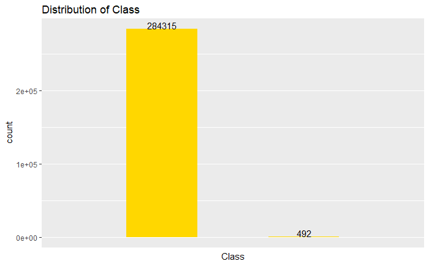

```r
# Distribution of Class
q <- ggplot(data = creditcard, aes(x=Class)) + geom_bar(position = position_dodge(), fill = "Gold", width = 0.5)+scale_x_discrete() + geom_text(stat = 'count', aes(label=..count..), vjust=0) + ggtitle("Distribution of Class")
q
```

```r
#It is certain that number Fraud transactions are much less compared to the Genuine transactions.
```

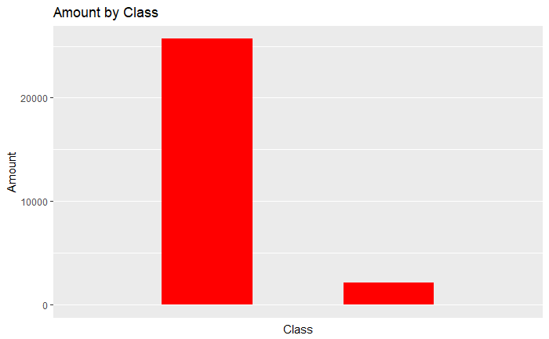

```r
# Distribution of Transaction Amount by Class
p <- ggplot(data=creditcard, aes(x=Class, y=Amount, label =Amount, fill = cond)) + geom_bar(position=position_dodge(), fill = "Red", width=0.5, stat = "identity", aes(fill = cond2))+scale_x_discrete() + ggtitle("Amount by Class")
p
```

```r
#Aggregating total transaction amount used by bank in regards to "Genuine" & "Fraud"
amount_agg <- aggregate(Amount ~ Class, creditcard, sum)
amount_agg
```

| Class | Amount |
| --- | --- |
| 0 | 25102462.04 |
| 1 | 60127.97 |

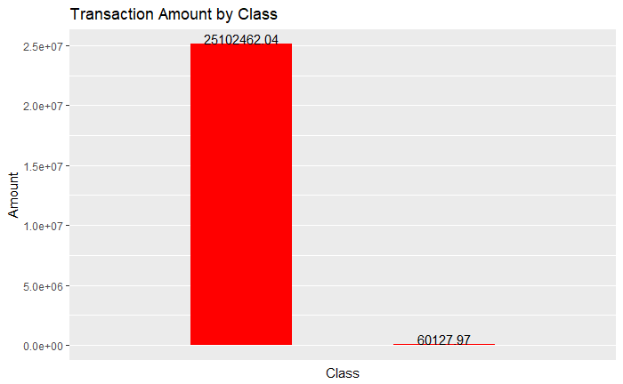

```r
p1 <- ggplot(data=amount_agg, aes(x=Class, y=Amount, label =Amount)) + geom_bar(position=position_dodge(), fill = "Red", width=0.5, stat = "identity")+scale_x_discrete() + ggtitle("Transaction Amount by Class") + geom_text(vjust=0)
p1
```

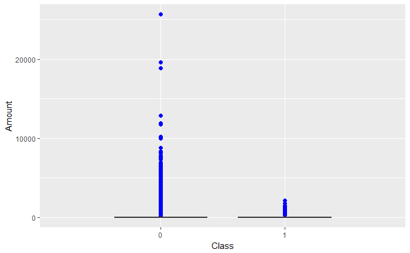

```r
# BoxPlot for Amount by Class
ggplot(data=creditcard, aes(Class, Amount, group=Class))+geom_boxplot(position=position_dodge(), outlier.colour="blue", outlier.shape=16,  outlier.size=2, notch=FALSE) + scale_x_discrete(limits=c(0,1))+ scale_fill_grey()
```

#### Fraud Transactions are of lower value from the results. Also, we know that number of fraud transactions are much less and hence apparantly we can conclude that amount would also be less unless large amount of transactions done to the defaulter. Which we will analyze further.

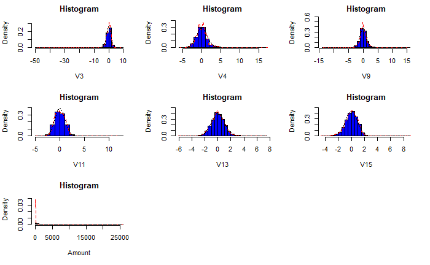

```r
# Histograms to visualize some PCA transformed features
multi.hist(creditcard[, c(4,5,10,12,14,16,30)], density = TRUE, bcol="Blue", dcol=c("red","black"),dlty=c("dashed","dotted"), main = "Histogram")
```

### (c) Detecting Outliers:

#### As we know that whole dataset has all feature variables with numeric input. Therefore, lets identify and locate the outlier through calculating descriptive statistics, and visualizing it.

#### Features from V1 to V28 (i.e. total 28 feature variables) are already a PCA transformed features and hence it’s unlikely for them to have outliers, since their values fits around the value of o and 1.

#### While other 2 feature variable (i.e. “Time” and “Amount”) are numeric and mught have outliers lying in it. But both are the variables which eventually can be considered as features with legitimate values and we must consider them in order to further train and evalute the model.

```r
summary(creditcard$Amount)

a <- mean(creditcard$Amount)
b <- sd(creditcard$Amount)

z_score <- ((a) - (creditcard$Amount))/(b)

z_score <- abs(z_score)

outliers <- which(z_score>3)
head(outliers)
```

[output not shown]

#### As per the analysis from z-score for all records of the dataset, there seems to be many outliers considering the thresold of z-score>3. But, let’s consider some domain knowledge here, and therefore we would not remove outliers detected in a column “Amount”. The reason for doing this would be, firstly it’s bank data and “Amount” is always remain the most significant factor in determining or predicting the goal of the project (i.e. “Class”). Besides, we are considering there are no constraints to the bank in giving out the loan to their customer. Hence, it could be acceptable to consider the distinct and non-uniformly distributed data on it.

#### Therefore, we are not removing the outliers of a specific “Amount” column and will continue further analysis as per the requirements.

### (d) Correlation/Collinearity Analysis:

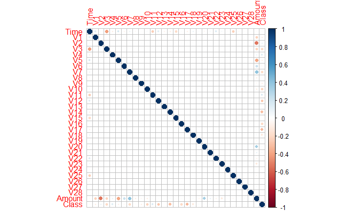

```r
library(corrplot)
correlations <- cor(creditcard,method="pearson")
corrplot(correlations, method = "circle")
```

### (III) Data Cleaning & Shaping:

### (e) Data Imputation:

#### But, let’s implement the imputation on a New.derived_df (i.e. creditcard dataset, including one derived features Cols.mean).

#### We will impute outliers that we’ve determined previously for the “Amount” column using z-score standardization. Records having z_score > 3 would be considered outlier in this case for implementation and would be required to impute.

#### We will implement “Average” imputation method.

```r
New.derived_df <- data.frame(creditcard)
New.derived_df[outliers,30] <- mean(New.derived_df$Amount)
summary(creditcard$Amount)
```

```
    Min.  1st Qu.   Median     Mean  3rd Qu.     Max.
    0.00     5.60    22.00    88.35    77.17 25691.16
```

```r
summary(New.derived_df$Amount)
```

```
   Min. 1st Qu.  Median    Mean 3rd Qu.    Max.
   0.00    5.60   22.00   67.26   77.17  838.70
```

#### We’ve imputed the outliers of the “Amount” column by Average imputation method. But, as I’ve explained earlier the important signicance of the “Amount” has on the prediction we will not consider imputation and continue further prediction analysis with original value of the “creditcard” dataset.

#### This implementation is just for the sake of requirement in order to ensure that we are aware of such imputation methods and “Average” is one of them.

### (f) Normalization/Standardization of feature values:

#### Normalization/Standrdization are the methods which plays an important role while before we plan to perform feature engineering on the them and then eventually figure out which are the variables that are statistically significant in order to use in training our model on the dataset.

#### Besides, there are many algorithms whose performance completely depends on the size, dimensionality, their values range, etc in order to predict output with maximum accuracy. That is where this methods comes in a role.

```r
summary(creditcard)
```

```
      Time              V1                  V2                  V3
 Min.   :     0   Min.   :-56.40751   Min.   :-72.71573   Min.   :-48.3256
 1st Qu.: 54202   1st Qu.: -0.92037   1st Qu.: -0.59855   1st Qu.: -0.8904
 Median : 84692   Median :  0.01811   Median :  0.06549   Median :  0.1799
 Mean   : 94814   Mean   :  0.00000   Mean   :  0.00000   Mean   :  0.0000
 3rd Qu.:139321   3rd Qu.:  1.31564   3rd Qu.:  0.80372   3rd Qu.:  1.0272
 Max.   :172792   Max.   :  2.45493   Max.   : 22.05773   Max.   :  9.3826
       V4                 V5                   V6                 V7
 Min.   :-5.68317   Min.   :-113.74331   Min.   :-26.1605   Min.   :-43.5572
 1st Qu.:-0.84864   1st Qu.:  -0.69160   1st Qu.: -0.7683   1st Qu.: -0.5541
 Median :-0.01985   Median :  -0.05434   Median : -0.2742   Median :  0.0401
 Mean   : 0.00000   Mean   :   0.00000   Mean   :  0.0000   Mean   :  0.0000
 3rd Qu.: 0.74334   3rd Qu.:   0.61193   3rd Qu.:  0.3986   3rd Qu.:  0.5704
 Max.   :16.87534   Max.   :  34.80167   Max.   : 73.3016   Max.   :120.5895
       V8                  V9                 V10                 V11
 Min.   :-73.21672   Min.   :-13.43407   Min.   :-24.58826   Min.   :-4.79747
 1st Qu.: -0.20863   1st Qu.: -0.64310   1st Qu.: -0.53543   1st Qu.:-0.76249
 Median :  0.02236   Median : -0.05143   Median : -0.09292   Median :-0.03276
 Mean   :  0.00000   Mean   :  0.00000   Mean   :  0.00000   Mean   : 0.00000
 3rd Qu.:  0.32735   3rd Qu.:  0.59714   3rd Qu.:  0.45392   3rd Qu.: 0.73959
 Max.   : 20.00721   Max.   : 15.59500   Max.   : 23.74514   Max.   :12.01891
      V12                V13                V14                V15
 Min.   :-18.6837   Min.   :-5.79188   Min.   :-19.2143   Min.   :-4.49894
 1st Qu.: -0.4056   1st Qu.:-0.64854   1st Qu.: -0.4256   1st Qu.:-0.58288
 Median :  0.1400   Median :-0.01357   Median :  0.0506   Median : 0.04807
 Mean   :  0.0000   Mean   : 0.00000   Mean   :  0.0000   Mean   : 0.00000
 3rd Qu.:  0.6182   3rd Qu.: 0.66251   3rd Qu.:  0.4931   3rd Qu.: 0.64882
 Max.   :  7.8484   Max.   : 7.12688   Max.   : 10.5268   Max.   : 8.87774
      V16                 V17                 V18                 V19
 Min.   :-14.12985   Min.   :-25.16280   Min.   :-9.498746   Min.   :-7.213527
 1st Qu.: -0.46804   1st Qu.: -0.48375   1st Qu.:-0.498850   1st Qu.:-0.456299
 Median :  0.06641   Median : -0.06568   Median :-0.003636   Median : 0.003735
 Mean   :  0.00000   Mean   :  0.00000   Mean   : 0.000000   Mean   : 0.000000
 3rd Qu.:  0.52330   3rd Qu.:  0.39968   3rd Qu.: 0.500807   3rd Qu.: 0.458949
 Max.   : 17.31511   Max.   :  9.25353   Max.   : 5.041069   Max.   : 5.591971
      V20                 V21                 V22                  V23
 Min.   :-54.49772   Min.   :-34.83038   Min.   :-10.933144   Min.   :-44.80774
 1st Qu.: -0.21172   1st Qu.: -0.22839   1st Qu.: -0.542350   1st Qu.: -0.16185
 Median : -0.06248   Median : -0.02945   Median :  0.006782   Median : -0.01119
 Mean   :  0.00000   Mean   :  0.00000   Mean   :  0.000000   Mean   :  0.00000
 3rd Qu.:  0.13304   3rd Qu.:  0.18638   3rd Qu.:  0.528554   3rd Qu.:  0.14764
 Max.   : 39.42090   Max.   : 27.20284   Max.   : 10.503090   Max.   : 22.52841
      V24                V25                 V26                V27
 Min.   :-2.83663   Min.   :-10.29540   Min.   :-2.60455   Min.   :-22.565679
 1st Qu.:-0.35459   1st Qu.: -0.31715   1st Qu.:-0.32698   1st Qu.: -0.070840
 Median : 0.04098   Median :  0.01659   Median :-0.05214   Median :  0.001342
 Mean   : 0.00000   Mean   :  0.00000   Mean   : 0.00000   Mean   :  0.000000
 3rd Qu.: 0.43953   3rd Qu.:  0.35072   3rd Qu.: 0.24095   3rd Qu.:  0.091045
 Max.   : 4.58455   Max.   :  7.51959   Max.   : 3.51735   Max.   : 31.612198
      V28                Amount             Class
 Min.   :-15.43008   Min.   :    0.00   Min.   :0.000000
 1st Qu.: -0.05296   1st Qu.:    5.60   1st Qu.:0.000000
 Median :  0.01124   Median :   22.00   Median :0.000000
 Mean   :  0.00000   Mean   :   88.35   Mean   :0.001728
 3rd Qu.:  0.07828   3rd Qu.:   77.17   3rd Qu.:0.000000
 Max.   : 33.84781   Max.   :25691.16   Max.   :1.000000
```

#### Lets perform Normalization/Standardization on only two feature variables “Amount” and “Time”. Since, we know that out of 31 feature variables 28 are already PCA transformed features and hence there remains no need to perform standardization and perform PCA on them again. And last one is target variable “Class”.

```r
dataf1 <- data.frame(creditcard)
# Z-Score Standardization on "Amount"
dataf1$Amount <- ((mean(creditcard$Amount)) - (creditcard$Amount))/(sd(creditcard$Amount))
summary(dataf1$Amount)
```

```
      Min.    1st Qu.     Median       Mean    3rd Qu.       Max.
-102.36206    0.04472    0.26527    0.00000    0.33084    0.35323
```

```r
# Normalization on "Time"
normalize <- function(x) {
  return ((x - min(x)) / (max(x) - min(x))) }
dataf1$Time <- normalize(creditcard$Time)
summary(dataf1$Time)
```

```
   Min. 1st Qu.  Median    Mean 3rd Qu.    Max.
 0.0000  0.3137  0.4901  0.5487  0.8063  1.0000
```

### (g) Feature Engineering: Dummy Codes

#### As we’re certainly aware of the fact that, full dataset contains 31 feature variables and all of which are numeric input variables. Hence, there’s no need to create dummy code variables in order to satisfy the requirements to train the model.

### (other) Feature Engineering: Identifying which features are statistically significant

#### Before standardizing and PCA transforming all required features in order to train the model, let’s build Multiple Regression model which will eventually help us to identify whether which features are worth performing further analysis.

```r
model_mult_reg <- lm(Class ~., data = creditcard)
summary(model_mult_reg)
```

```
Call:
lm(formula = Class ~ ., data = creditcard)

Residuals:
     Min       1Q   Median       3Q      Max
-1.06423 -0.00165  0.00002  0.00100  1.00054

Coefficients:
              Estimate Std. Error  t value Pr(>|t|)
(Intercept)  1.513e-03  1.708e-04    8.863  < 2e-16 ***
Time        -4.394e-09  1.554e-09   -2.828 0.004687 **
V1          -1.929e-03  3.532e-05  -54.609  < 2e-16 ***
V2           2.869e-03  6.854e-05   41.857  < 2e-16 ***
V3          -5.094e-03  4.864e-05 -104.742  < 2e-16 ***
V4           3.774e-03  4.055e-05   93.064  < 2e-16 ***
V5          -2.331e-03  6.594e-05  -35.359  < 2e-16 ***
V6          -1.660e-03  5.064e-05  -32.772  < 2e-16 ***
V7          -6.845e-03  7.446e-05  -91.930  < 2e-16 ***
V8           8.387e-04  4.794e-05   17.496  < 2e-16 ***
V9          -3.624e-03  4.957e-05  -73.105  < 2e-16 ***
V10         -8.099e-03  5.246e-05 -154.391  < 2e-16 ***
V11          6.250e-03  5.569e-05  112.238  < 2e-16 ***
V12         -1.079e-02  5.467e-05 -197.322  < 2e-16 ***
V13         -2.140e-04  5.431e-05   -3.940 8.14e-05 ***
V14         -1.319e-02  5.703e-05 -231.281  < 2e-16 ***
V15         -2.276e-04  6.064e-05   -3.754 0.000174 ***
V16         -9.304e-03  6.144e-05 -151.433  < 2e-16 ***
V17         -1.600e-02  6.371e-05 -251.089  < 2e-16 ***
V18         -5.577e-03  6.520e-05  -85.533  < 2e-16 ***
V19          1.905e-03  6.741e-05   28.258  < 2e-16 ***
V20          2.823e-04  1.081e-04    2.611 0.009034 **
V21          2.040e-03  7.825e-05   26.070  < 2e-16 ***
V22          2.469e-04  7.740e-05    3.191 0.001420 **
V23          1.606e-04  9.275e-05    1.731 0.083402 .
V24         -5.159e-04  8.890e-05   -5.803 6.54e-09 ***
V25          3.341e-04  1.098e-04    3.043 0.002346 **
V26          3.776e-04  1.118e-04    3.378 0.000731 ***
V27          1.678e-03  1.340e-04   12.525  < 2e-16 ***
V28          1.138e-03  1.632e-04    6.976 3.05e-12 ***
Amount       7.139e-06  7.490e-07    9.531  < 2e-16 ***
---
Signif. codes:  0 ‘***’ 0.001 ‘**’ 0.01 ‘*’ 0.05 ‘.’ 0.1 ‘ ’ 1

Residual standard error: 0.02872 on 284776 degrees of freedom
Multiple R-squared:  0.5216,    Adjusted R-squared:  0.5216
F-statistic: 1.035e+04 on 30 and 284776 DF,  p-value: < 2.2e-16
```

### (h) Feature Engineering: PCA

#### Our feature variable V1 TO V28 are already PCA transformed principal components.

#### We’ll perform PCA transformation feature engineering on “Amount” and “Time” with Normalized and Standardized dataset “Dataf1”

```r
# Created variable/dataframe of two columns "Amount" & "Time"
std_col <- dataf1[,c(1,30)]
summary(std_col)
```

```
      Time            Amount
 Min.   :0.0000   Min.   :-102.36206
 1st Qu.:0.3137   1st Qu.:   0.04472
 Median :0.4901   Median :   0.26527
 Mean   :0.5487   Mean   :   0.00000
 3rd Qu.:0.8063   3rd Qu.:   0.33084
 Max.   :1.0000   Max.   :   0.35323
```

```r
str(std_col)
```

```
'data.frame':   284807 obs. of  2 variables:
 $ Time  : num  0.00 0.00 5.79e-06 5.79e-06 1.16e-05 ...
 $ Amount: num  -0.245 0.3425 -1.1607 -0.1405 0.0734 ...
```

```r
# Used "prcomp()" of stats package to PCA transform the features
pca_transformed <- prcomp(std_col)
summary(pca_transformed)
```

```
Importance of components%s:
                          PC1     PC2
Standard deviation     1.0000 0.27481
Proportion of Variance 0.9298 0.07022
Cumulative Proportion  0.9298 1.00000
```

```r
print(pca_transformed)
```

```
Standard deviations (1, .., p=2):
[1] 1.0000046 0.2748117

Rotation (n x k) = (2 x 2):
                PC1          PC2
Time   -0.003150067 -0.999995039
Amount -0.999995039  0.003150067
```

```r
# Loadings of the features records
head(pca_transformed$x)
```

```
             PC1       PC2
[1,]  0.24669111 0.5479423
[2,] -0.34074375 0.5497928
[3,]  1.16240661 0.5450520
[4,]  0.14226178 0.5482655
[5,] -0.07167439 0.5489336
[6,] -0.33682568 0.5497689
```

```r
dim(pca_transformed$x)
```

```
[1] 284807      2
```

#### Lets combine and make a final dataframe of statistically significant-PCA transformed feature variables.

```r
#Combining specific columns from both/different dataframes
dataf2 <- data.frame(dataf1[, c(2:29,31)], pca_transformed$x)
#Reordering the columns, to ensure any mistakes to happen further
dataf2 <- dataf2[c(30,1:28,31,29)]
#Changing column name to the original from "PC1" (i.e. Time)
names(dataf2)[1] <- paste("Time")
#Changing column name to the original from "PC2" (i.e. Amount)
names(dataf2)[30] <- paste("Amount")
str(dataf2)
```

```
'data.frame':   284807 obs. of  31 variables:
 $ Time  : num  0.2467 -0.3407 1.1624 0.1423 -0.0717 ...
 $ V1    : num  -1.36 1.192 -1.358 -0.966 -1.158 ...
 $ V2    : num  -0.0728 0.2662 -1.3402 -0.1852 0.8777 ...
 $ V3    : num  2.536 0.166 1.773 1.793 1.549 ...
 $ V4    : num  1.378 0.448 0.38 -0.863 0.403 ...
 $ V5    : num  -0.3383 0.06 -0.5032 -0.0103 -0.4072 ...
 $ V6    : num  0.4624 -0.0824 1.8005 1.2472 0.0959 ...
 $ V7    : num  0.2396 -0.0788 0.7915 0.2376 0.5929 ...
 $ V8    : num  0.0987 0.0851 0.2477 0.3774 -0.2705 ...
 $ V9    : num  0.364 -0.255 -1.515 -1.387 0.818 ...
 $ V10   : num  0.0908 -0.167 0.2076 -0.055 0.7531 ...
 $ V11   : num  -0.552 1.613 0.625 -0.226 -0.823 ...
 $ V12   : num  -0.6178 1.0652 0.0661 0.1782 0.5382 ...
 $ V13   : num  -0.991 0.489 0.717 0.508 1.346 ...
```

[output cut: 17 more lines]

### (i) Feature Engineering: New Derived Features

#### This dataset doen’t really require any necessary derived features. But, I will try deriving new features accordingly and give effort to improve the model and compare it to one without derived features and then analyze that why and how they differ in a sense to predict the classification with maximum accuracy with it’s robust model.

```r
New.derived_df1 <- data.frame(creditcard)
summary(New.derived_df1$Amount)
```

```
    Min.  1st Qu.   Median     Mean  3rd Qu.     Max.
    0.00     5.60    22.00    88.35    77.17 25691.16
```

```r
New.derived_df1$Cols.mean = apply(New.derived_df1[,c(2:30)],1,mean)
str(New.derived_df)
```

```
'data.frame':   284807 obs. of  31 variables:
 $ Time  : num  0 0 1 1 2 2 4 7 7 9 ...
 $ V1    : num  -1.36 1.192 -1.358 -0.966 -1.158 ...
 $ V2    : num  -0.0728 0.2662 -1.3402 -0.1852 0.8777 ...
 $ V3    : num  2.536 0.166 1.773 1.793 1.549 ...
 $ V4    : num  1.378 0.448 0.38 -0.863 0.403 ...
 $ V5    : num  -0.3383 0.06 -0.5032 -0.0103 -0.4072 ...
 $ V6    : num  0.4624 -0.0824 1.8005 1.2472 0.0959 ...
 $ V7    : num  0.2396 -0.0788 0.7915 0.2376 0.5929 ...
 $ V8    : num  0.0987 0.0851 0.2477 0.3774 -0.2705 ...
 $ V9    : num  0.364 -0.255 -1.515 -1.387 0.818 ...
 $ V10   : num  0.0908 -0.167 0.2076 -0.055 0.7531 ...
 $ V11   : num  -0.552 1.613 0.625 -0.226 -0.823 ...
 $ V12   : num  -0.6178 1.0652 0.0661 0.1782 0.5382 ...
 $ V13   : num  -0.991 0.489 0.717 0.508 1.346 ...
```

[output cut: 17 more lines]

```r
New.derived_df1$Cols.mean <- abs(New.derived_df1$Cols.mean)
# Multiple Regression model
try_mult <- lm((Class)~.,data = New.derived_df1)
summary(try_mult)
```

```
Call:
lm(formula = (Class) ~ ., data = New.derived_df1)

Residuals:
     Min       1Q   Median       3Q      Max
-1.06660 -0.00165  0.00002  0.00100  1.00055

Coefficients:
              Estimate Std. Error  t value Pr(>|t|)
(Intercept)  1.525e-03  1.709e-04    8.925  < 2e-16 ***
Time        -4.427e-09  1.554e-09   -2.849 0.004391 **
V1          -1.912e-03  3.667e-05  -52.138  < 2e-16 ***
V2           2.907e-03  7.217e-05   40.283  < 2e-16 ***
V3          -5.082e-03  4.914e-05 -103.427  < 2e-16 ***
V4           3.811e-03  4.598e-05   82.884  < 2e-16 ***
V5          -2.307e-03  6.754e-05  -34.155  < 2e-16 ***
V6          -1.636e-03  5.248e-05  -31.182  < 2e-16 ***
V7          -6.851e-03  7.455e-05  -91.905  < 2e-16 ***
V8           8.487e-04  4.830e-05   17.572  < 2e-16 ***
V9          -3.606e-03  5.066e-05  -71.183  < 2e-16 ***
V10         -8.098e-03  5.247e-05 -154.339  < 2e-16 ***
V11          6.288e-03  5.999e-05  104.812  < 2e-16 ***
V12         -1.078e-02  5.480e-05 -196.724  < 2e-16 ***
V13         -1.895e-04  5.618e-05   -3.374 0.000741 ***
V14         -1.318e-02  5.730e-05 -230.058  < 2e-16 ***
V15         -2.025e-04  6.241e-05   -3.245 0.001176 **
V16         -9.293e-03  6.173e-05 -150.545  < 2e-16 ***
V17         -1.601e-02  6.399e-05 -250.122  < 2e-16 ***
V18         -5.565e-03  6.556e-05  -84.887  < 2e-16 ***
V19          1.935e-03  6.962e-05   27.789  < 2e-16 ***
V20          3.142e-04  1.098e-04    2.863 0.004198 **
V21          2.049e-03  7.841e-05   26.125  < 2e-16 ***
V22          2.830e-04  8.026e-05    3.526 0.000421 ***
V23          1.917e-04  9.455e-05    2.028 0.042585 *
V24         -4.886e-04  9.034e-05   -5.408 6.37e-08 ***
V25          3.570e-04  1.106e-04    3.227 0.001251 **
V26          4.066e-04  1.131e-04    3.595 0.000324 ***
V27          1.699e-03  1.346e-04   12.627  < 2e-16 ***
V28          1.152e-03  1.634e-04    7.050 1.79e-12 ***
Amount       3.671e-05  1.742e-05    2.108 0.035044 *
Cols.mean   -8.571e-04  5.043e-04   -1.700 0.089215 .
---
Signif. codes:  0 ‘***’ 0.001 ‘**’ 0.01 ‘*’ 0.05 ‘.’ 0.1 ‘ ’ 1

Residual standard error: 0.02872 on 284775 degrees of freedom
Multiple R-squared:  0.5216,    Adjusted R-squared:  0.5216
F-statistic: 1.002e+04 on 31 and 284775 DF,  p-value: < 2.2e-16
```

#### After training a multiple regression model including our new derived feature, it seems that Cols.mean is not a statistically significant variable with p-value = 0.089 (i.e. >0.05) and therefore it won’t be making any sense to consider in our further analysis to train a robust predictive machine learning model.

# Phase 4 - Modeling:

### (j) Creating of Training & Validation subsets:

#### Before executing the method to subset the dataset, let’s determine the proportion of “Class” variable. Because, in order to avoid overfitting/underfitting the data and carry out the prediction classification accurately; we have to ensure the proportion of the “class” (i.e.target variable) and should be in both Training and Validation dataset as a Stratifies dataset.

```r
table(dataf2$Class)
```

```
     0      1
284315    492
```

```r
prop.table(table(dataf2$Class))*100
```

```
         0          1
99.8272514  0.1727486
```

```r
# Proportion depicts 99.83% - Genuine and 0.17% - Fraud in full dataset and is randomly fitted in records.
```

#### Firstly before partitioning the dataset in Training and Testing, let’s ensure and convert the target variable into the factor type. Since most of the supervised machine learning algorithm are created using that data-type as a target variable.

```r
dataf3 <- data.frame(dataf2)
dataf3$Class <- as.factor(dataf3$Class)
prop.table(table(dataf3$Class))
```

```
          0           1
0.998272514 0.001727486
```

#### In order to partition data in a stratified format as in with the same proportion of “class” variable distributed/splited in both training and testing dataset, let’s use “caret” package and further perform the task.

#### We know that our dataset in highly dimensional with 31 feature variables and 284807 records. Each machine learning algorithms takes high computation time (i.e. around 45-60 mins) to build/train the model on such big dataset (i.e. this case: 213605 records (75% of full data)).

#### Hence, we would be working on the 25% of the data of the full dataset; which comes around 71202 records.

#### The partition of the sample dataset (i.e. 25% data of the full dataset) would in a ratio of 75%-training and 25%-testing.

```r
set.seed(123)  #To ensure reusablity of the data to create the same results
data.credit <- sample(1:nrow(dataf3), round(0.25*nrow(dataf3)))
dataf3 <- dataf3[data.credit,]
partition <- createDataPartition(y = dataf3$Class, p = 0.75, list = FALSE)  #Split-ratio for training:testing is 75:25 percent respectively.
credit_training <- dataf3[partition, ]  #Training dataset
credit_testing <- dataf3[-partition, ]
table(credit_training$Class)
```

```
    0     1
53310    93
```

```r
prop.table(table(credit_training$Class))*100
```

```
         0          1
99.8258525  0.1741475
```

```r
table(credit_testing$Class)
```

```
    0     1
17769    30
```

```r
prop.table(table(credit_testing$Class))*100
```

```
         0          1
99.8314512  0.1685488
```

#### Seperated features variables and response variable by giving different vectors, in order to use to train the model and it’s use depends case to case (i.e. model to model)

```r
train_features <- credit_training[,1:30]
train_class <- credit_training[,31]
test_features <- credit_testing[,1:30]
test_class <- credit_testing[,31]
prop.table(table(train_class))*100
```

```
train_class
         0          1
99.8258525  0.1741475
```

```r
prop.table(table(test_class))*100
```

```
test_class
         0          1
99.8314512  0.1685488
```

#### Let’s make it certain, training a model on large dataset takes high computation time so for specific to that reason we’ll train our model on a training data of sample dataset; as I already made it clear.

#### But, in order to predict the classification; we can definitely use the full test dataset (i.e. 25% of full dataset).

#### Therefore, let’s partition the data on the full dataset (i.e. original dataset) with 25%-testing and rest training considering equal proportion of the “class”.

#### We will just use the test dataset from this against prediting the classification on model.

```r
dataf3_fulldata <- data.frame(dataf2)
dataf3_fulldata$Class <- as.factor(dataf3_fulldata$Class)
set.seed(123)
partition_fulldata <- createDataPartition(y = dataf3_fulldata$Class, p = 0.75, list = FALSE)  #Split-ratio for training:testing is 75:25 percent respectively.
credit_training_fulldata <- dataf3_fulldata[partition_fulldata, ]
credit_testing_fulldata <- dataf3_fulldata[-partition_fulldata, ]  #Testing dataset
table(credit_training_fulldata$Class)
```

```
     0      1
213237    369
```

```r
prop.table(table(credit_training_fulldata$Class))*100
```

```
        0         1
99.827252  0.172748
```

```r
table(credit_testing_fulldata$Class)
```

```
    0     1
71078   123
```

```r
prop.table(table(credit_testing_fulldata$Class))*100
```

```
         0          1
99.8272496  0.1727504
```

```r
test_features_fulldata <- credit_testing_fulldata[,1:30]
test_class_fulldata <- credit_testing_fulldata[,31]
```

### (k) Construction of atleast three models:

#### Our goal is to train one highly preferable and robust machine learning model which can be taken in deployment and improves the performance of the firm.

#### Firstly, let’s try and build every possible supervised machine learning models. Then we’ll evaluate them basis on absolute accuracy and AUC. After doing so, we’ll use 3-4 best machine learning models to further evaluate the fit and to perform further analysis which helps us to reach our goal.

# Model 1: k-Nearest Neighbor Classifier

#### Using “class” package & “knn()” function

```r
library(class)
pred_knn <- knn(train = train_features, test = test_features_fulldata, cl = train_class, k=5)
```

#### Evaluation of the model with Absolute Accuracy and AUC against the testing dataset; which is partitioned on full dataset.

```r
library(caret)
confusionMatrix(pred_knn, test_class_fulldata) #Evaluation (Accuracy: 0.9995, No Information Rate: 0.9983)
```

```
Confusion Matrix and Statistics

          Reference
Prediction     0     1
         0 71073    30
         1     5    93

               Accuracy : 0.9995
                 95% CI : (0.9993, 0.9997)
    No Information Rate : 0.9983
    P-Value [Acc > NIR] : < 2.2e-16

                  Kappa : 0.8414
 Mcnemar's Test P-Value : 4.976e-05

            Sensitivity : 0.9999
            Specificity : 0.7561
         Pos Pred Value : 0.9996
         Neg Pred Value : 0.9490
             Prevalence : 0.9983
         Detection Rate : 0.9982
   Detection Prevalence : 0.9986
      Balanced Accuracy : 0.8780

       'Positive' Class : 0
```

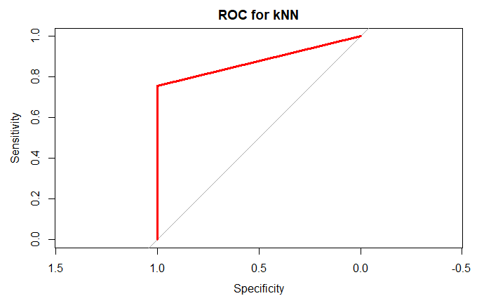

```r
library(pROC)
roc_kNN <- roc(as.numeric(test_class_fulldata), as.numeric(pred_knn))
plot.roc(roc_kNN, col="Red", lwd=3, main = "ROC for kNN")
```

```r
auc(roc_kNN)  #Area under the curve: 0.8780136
```

```
Area under the curve: 0.878
```

# Model 2: Naive Bayes

#### Using “e1071” package & “naiveBayes()” function

```r
library(e1071)
model_NB <- naiveBayes(train_features, train_class)
pred_NB <- predict(model_NB, credit_testing_fulldata)
```

#### Evaluation of the model with Absolute Accuracy and AUC - Naive Bayes against the testing dataset; which is partitioned on full dataset.

```r
confusionMatrix(pred_NB, test_class_fulldata)  #Evaluation (Accuracy: 0.9770, No Information Rate: 0.9983)
```

```
Confusion Matrix and Statistics

          Reference
Prediction     0     1
         0 69463    18
         1  1615   105

               Accuracy : 0.9771
                 95% CI : (0.9759, 0.9782)
    No Information Rate : 0.9983
    P-Value [Acc > NIR] : 1

                  Kappa : 0.1111
 Mcnemar's Test P-Value : <2e-16

            Sensitivity : 0.97728
            Specificity : 0.85366
         Pos Pred Value : 0.99974
         Neg Pred Value : 0.06105
             Prevalence : 0.99827
         Detection Rate : 0.97559
   Detection Prevalence : 0.97584
      Balanced Accuracy : 0.91547

       'Positive' Class : 0
```

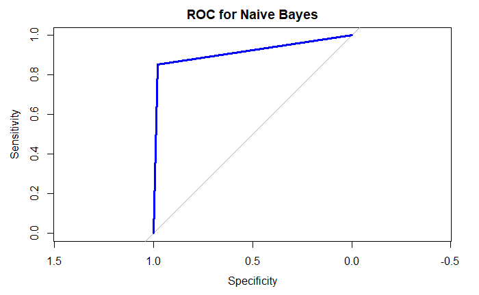

```r
library(pROC)
roc_NB <- roc(as.numeric(test_class_fulldata), as.numeric(pred_NB))
plot.roc(roc_NB, col="Blue", lwd=3, main = "ROC for Naive Bayes")
```

```r
auc(roc_NB)  #Area under the curve: 0.9154685
```

```
Area under the curve: 0.9155
```

# Model 3: Decision Trees

#### Using “C50” package & “C5.0()” function

```r
library(C50)
model_Dec.trees <- C5.0(train_features, train_class)
model_Dec.trees
```

```
Call:
C5.0.default(x = train_features, y = train_class)

Classification Tree
Number of samples: 53403
Number of predictors: 30

Tree size: 4

Non-standard options: attempt to group attributes
```

```r
summary(model_Dec.trees)
```

```
Call:
C5.0.default(x = train_features, y = train_class)


C5.0 [Release 2.07 GPL Edition]     Sat Apr 21 19:02:47 2018
-------------------------------

Class specified by attribute `outcome'

Read 53403 cases (31 attributes) from undefined.data

Decision tree:

V12 > -4.381078: 0 (53329/38)
V12 <= -4.381078:
:...V4 <= -0.4197211: 0 (4)
    V4 > -0.4197211:
    :...V11 <= 7.588741: 1 (63/9)
        V11 > 7.588741: 0 (7/1)


Evaluation on training data (53403 cases):

        Decision Tree
      ----------------
      Size      Errors

         4   48( 0.1%)   <<


       (a)   (b)    <-classified as
      ----  ----
     53301     9    (a): class 0
        39    54    (b): class 1


    Attribute usage:

    100.00% V12
      0.14% V4
      0.13% V11


Time: 2.8 secs
```

```r
pred_Dec.trees <- predict(model_Dec.trees, credit_testing_fulldata)
```

#### Evaluation of the model with Absolute Accuracy and AUC - Decision Trees against the testing dataset; which is partitioned on full dataset.

```r
confusionMatrix(pred_Dec.trees, test_class_fulldata)  #Evaluation (Accuracy: 0.9992, No Information Rate: 0.9983)
```

```
Confusion Matrix and Statistics

          Reference
Prediction     0     1
         0 71069    51
         1     9    72

               Accuracy : 0.9992
                 95% CI : (0.9989, 0.9994)
    No Information Rate : 0.9983
    P-Value [Acc > NIR] : 2.128e-10

                  Kappa : 0.7055
 Mcnemar's Test P-Value : 1.203e-07

            Sensitivity : 0.9999
            Specificity : 0.5854
         Pos Pred Value : 0.9993
         Neg Pred Value : 0.8889
             Prevalence : 0.9983
         Detection Rate : 0.9981
   Detection Prevalence : 0.9989
      Balanced Accuracy : 0.7926

       'Positive' Class : 0
```

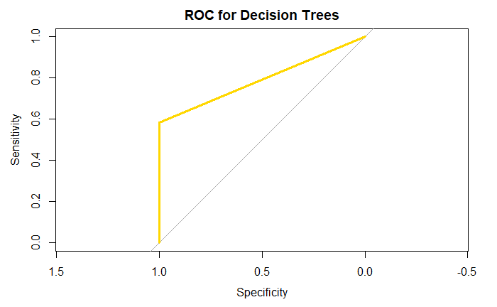

```r
library(pROC)
roc_Dec.trees <- roc(as.numeric(test_class_fulldata), as.numeric(pred_Dec.trees))
plot.roc(roc_Dec.trees, col="Gold", lwd=3, main = "ROC for Decision Trees")
```

```r
auc(roc_Dec.trees) #Area under the curve: 0.7926196
```

```
Area under the curve: 0.7926
```

# Model 4: Logistic Regression

#### As we know that, Logistic regression results into the probabilities of the binary class variables. It will require the “class” variable in a numeric format. Therefore, performed partitioning on the dataset again with “class” variable in a same datatype of “numeric”

#### Training/Testing for Logistic Regression

```r
dataf4_Logistic <- data.frame(dataf2)
str(dataf4_Logistic)
```

```
'data.frame':   284807 obs. of  31 variables:
 $ Time  : num  0.2467 -0.3407 1.1624 0.1423 -0.0717 ...
 $ V1    : num  -1.36 1.192 -1.358 -0.966 -1.158 ...
 $ V2    : num  -0.0728 0.2662 -1.3402 -0.1852 0.8777 ...
 $ V3    : num  2.536 0.166 1.773 1.793 1.549 ...
 $ V4    : num  1.378 0.448 0.38 -0.863 0.403 ...
 $ V5    : num  -0.3383 0.06 -0.5032 -0.0103 -0.4072 ...
 $ V6    : num  0.4624 -0.0824 1.8005 1.2472 0.0959 ...
 $ V7    : num  0.2396 -0.0788 0.7915 0.2376 0.5929 ...
 $ V8    : num  0.0987 0.0851 0.2477 0.3774 -0.2705 ...
 $ V9    : num  0.364 -0.255 -1.515 -1.387 0.818 ...
 $ V10   : num  0.0908 -0.167 0.2076 -0.055 0.7531 ...
 $ V11   : num  -0.552 1.613 0.625 -0.226 -0.823 ...
 $ V12   : num  -0.6178 1.0652 0.0661 0.1782 0.5382 ...
 $ V13   : num  -0.991 0.489 0.717 0.508 1.346 ...
```

[output cut: 17 more lines]

```r
set.seed(123)
library(caTools)
partition_Logistic <- sample.split(dataf4_Logistic$Class, SplitRatio = 0.75)
credit_training_Logistic <- subset(dataf4_Logistic, partition_Logistic == TRUE)
credit_testing_Logistic <- subset(dataf4_Logistic, partition_Logistic == FALSE)
dim(credit_training_Logistic)
```

```
[1] 213605     31
```

```r
dim(credit_testing_Logistic)
```

```
[1] 71202    31
```

```r
prop.table(table(credit_training_Logistic$Class))
```

```
          0           1
0.998272512 0.001727488
```

```r
prop.table(table(credit_testing_Logistic$Class))
```

```
         0          1
0.99827252 0.00172748
```